# Brief intro to SDM: presence-only vs presence-absence data and methods

Petr Keil, data from Florencia Grattarola

10/16/2022

To do: - add literature/references - add concluding points

# 1 Introduction

- Species Distribution Modelling (a.k.a. Niche Modelling) aims to predict **where species live** from a limited set of observation.
- Sometimes it aims to estimate species’ **niches** from its distribution.
- It’s a **huge** field, massively used in applied ecology and conservation.
- It’s a young field (last 20 years), and it is full of **problems and challenges**.

## 1.1 Goals

- explain basic idea of SDM
- to show an **example use of SDM**, and to demonstrate the challenges it faces
- to show the difference between presence-only and presence-absence data
- to show basic methods for both types. These will be: GLM/GAM, random forest, MaxEnt
- to compare outputs of different methods

## 1.2 Resources

- Species distribution modelling with R.J. Hijmans & Jane Elith [dismo package](https://rspatial.org/raster/sdm/).
- Damaris Zurell’s tutorial: https://damariszurell.github.io/SDM-Intro/
- ENM2020: A free online course and set of resources on modeling species niches and distributions: https://journals.ku.edu/jbi/article/view/15016

## 1.3 **Yaguarundí** (*Herpailurus yaguarundi*)

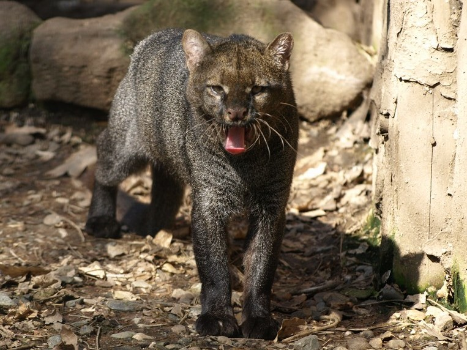

# 2 Load R libraries

If you don’t have any of these, just type `install.packages("name of the package")`

```r
# GIS libraries
library(sp) # handling shapefiles, i.e. polygons, lines, and points
library(raster) # handling rasters
library(rgdal) # handling projections and spatial data

# modelling libraries
library(randomForest) # random forest machine learning
library(mgcv) # generalized additive models
library(dismo) # suite of SDM methods, including maxent

# miscelaneous libraries
library(tidyverse) # for ggplot, pipes, and all sorts of gymnastics
library(rJava) # this loads automatically with dismo, but sometimes it's missing
```

# 3 Data

I’ve pre-processed all the spatial data and saved them in a single `.RData` file, so you just need to read it:

```r
# clean R workspace
rm(list = ls())

# important: set your working directory to the folder with the file
load("yaguarundi_SDM_data.RData")
```

## 3.1 Data exploration

This is the legend to the **bioclimatic variables**, which you can also find at https://www.worldclim.org/data/bioclim.html:

- BIO1 - Mean Annual Temperature
- BIO7 - Temperature Annual Range
- BIO12 - Annual Precipitation
- BIO15 - Precipitation Seasonality

# 4 Three types of approaches

**Presence-only methods** - Don’t need data on absences. They only estimate relative *habitat suitability*, not probability. Sensitive to spatial biases. Example: MaxEnt.

**Presence-pseudo absence methods** - Employ arbitrary ways to make artificial absences.

**Presence-absence methods** - Use presence/absence survey data. They estimate true probability. Sensitive to imperfect detections. Example: GLM.

# 5 Presence-only methods - MaxEnt

The best intro: [Cory Merrow’s tutorial](https://onlinelibrary.wiley.com/doi/full/10.1111/j.1600-0587.2013.07872.x)

Two main advantages: - Good performance - Ease of use

How MaxEnt works: *“MaxEnt takes a list of species presence locations as input, often called presence-only (PO) data, as well as a set of environmental predictors (e.g. precipitation, temperature) across a user-defined landscape that is divided into grid cells. From this landscape, MaxEnt extracts a sample of background locations that it contrasts against the presence locations (section III.A). Presence is unknown at background locations”* Merrow et al. (2013) Ecography.

### 5.0.1 Fit the MaxEnt model

```r
library(dismo)
mx <- dismo::maxent(x = PO.predictors, p = PTS)
```

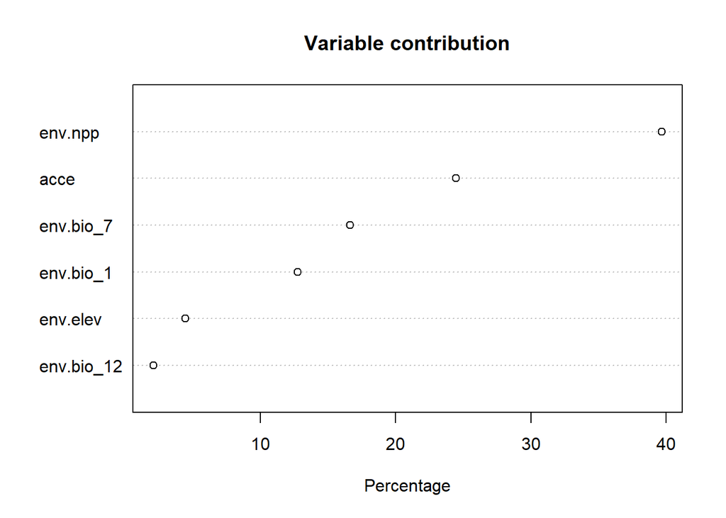

```r
# show variable importance
plot(mx)
```

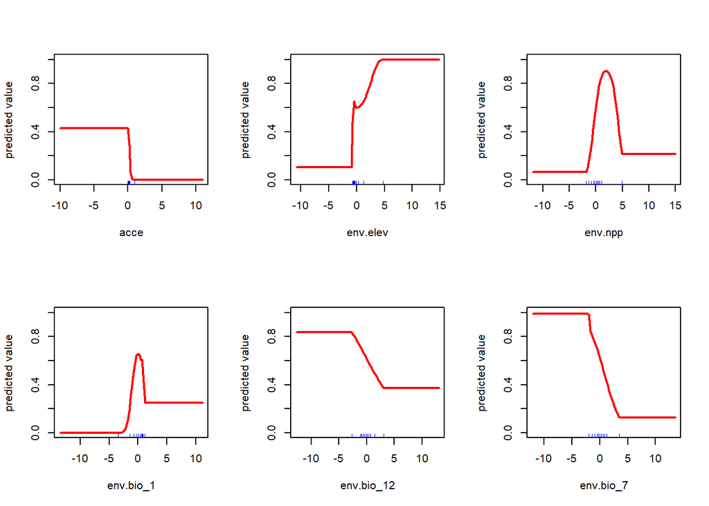

```r
# show the predictions
mx.raster <- predict(mx, x = PO.predictors)

# show response curves
response(mx)
```

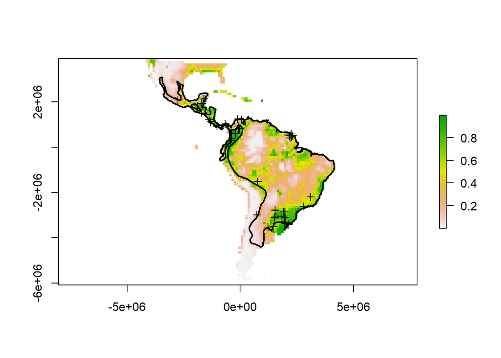

```r
# map the predicted environmental suitability
plot(mx.raster)
plot(yaguarundi_IUCN, col=NA, lwd=2, add=T)
plot(PTS, add=T)
```

# 6 Presence-absence data

```r
head(PA)
```

```
##   presabs       X        Y       area effort   env.elev   env.npp  env.bio_1
## 1       0 2147542 -3498938    2398303   2464 -1.0991322 0.4402945 -0.5870998
## 2       0 2179628 -3461387    2992037   3752 -1.1094159 0.1931954 -0.5241128
## 4       0 2159714 -3323251    2636198  18372 -1.0994782 1.5976997 -0.3085964
## 5       1 2263019 -3280965   15992690   1191  0.1626719 1.4158194 -1.5986569
## 6       1 2300868 -3249831  468832531   1640  0.1533710 0.9536826 -1.4800312
## 7       1 2366522 -3143000 1027057358   2006  0.7483091 1.2650790 -1.9651694
##   env.bio_12 env.bio_7 env.bio_15 log.area log.effort
## 1  -2.749738 -2.290882 -0.3366608 6.379904   3.391641
## 2  -2.643331 -2.362551 -0.3160202 6.475967   3.574263
## 4  -1.584319 -2.512669  0.1030300 6.420978   4.264156
## 5  -1.152089 -2.526681 -1.3135873 7.203922   3.075912
## 6  -1.350173 -2.421590 -1.3190820 8.671018   3.214844
## 7  -1.184872 -2.140868 -1.8408464 9.011595   3.302331
```

```r
summary(PA)
```

```
##     presabs             X                  Y                 area
##  Min.   :0.0000   Min.   :-3113704   Min.   :-3658283   Min.   :3.000e+02
##  1st Qu.:0.0000   1st Qu.: 2014515   1st Qu.:-2534613   1st Qu.:4.198e+05
##  Median :0.0000   Median : 2644844   Median :-2210233   Median :2.554e+06
##  Mean   :0.1801   Mean   : 2286423   Mean   :-1904409   Mean   :2.668e+08
##  3rd Qu.:0.0000   3rd Qu.: 2885693   3rd Qu.:-1579246   3rd Qu.:1.687e+07
##  Max.   :1.0000   Max.   : 4147027   Max.   : 2200913   Max.   :3.519e+10
##      effort          env.elev           env.npp            env.bio_1
##  Min.   :     4   Min.   :-1.10942   Min.   :-2.300826   Min.   :-4.912933
##  1st Qu.:    95   1st Qu.:-0.66033   1st Qu.:-0.602549   1st Qu.:-0.568190
##  Median :   482   Median :-0.18302   Median :-0.114866   Median : 0.039307
##  Mean   : 48682   Mean   : 0.00235   Mean   :-0.009131   Mean   :-0.002693
##  3rd Qu.:  2809   3rd Qu.: 0.27622   3rd Qu.: 0.608859   3rd Qu.: 0.805441
##  Max.   :852500   Max.   : 6.11421   Max.   : 4.397311   Max.   : 1.939093
##    env.bio_12          env.bio_7           env.bio_15           log.area
##  Min.   :-3.178679   Min.   :-2.609083   Min.   :-4.992978   Min.   : 2.477
##  1st Qu.:-0.585457   1st Qu.:-0.344642   1st Qu.:-0.405311   1st Qu.: 5.623
##  Median : 0.295023   Median : 0.141220   Median :-0.011877   Median : 6.407
##  Mean   : 0.006019   Mean   : 0.000306   Mean   :-0.001236   Mean   : 6.419
##  3rd Qu.: 0.605462   3rd Qu.: 0.540618   3rd Qu.: 0.725202   3rd Qu.: 7.227
##  Max.   : 4.312289   Max.   : 4.821100   Max.   : 2.158671   Max.   :10.546
##    log.effort
##  Min.   :0.6021
##  1st Qu.:1.9777
##  Median :2.6830
##  Mean   :2.8771
##  3rd Qu.:3.4485
##  Max.   :5.9307
```

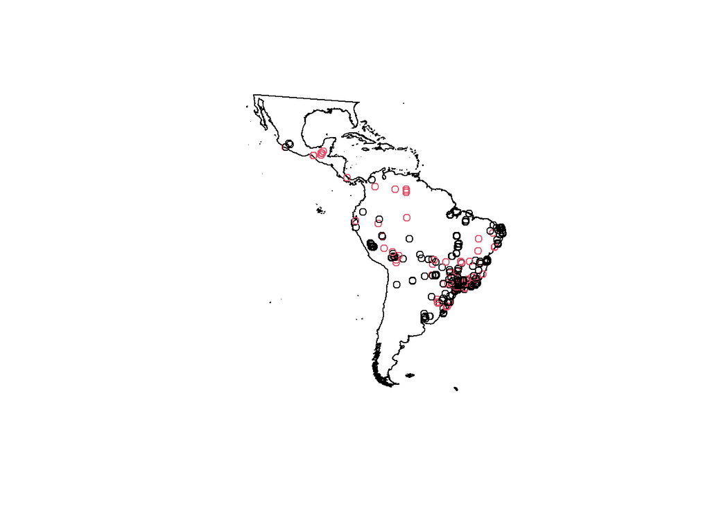

```r
# plot the data using the base R graphics
plot(Latam)
points(PA$X, PA$Y, col=as.factor(PA$presabs))
```

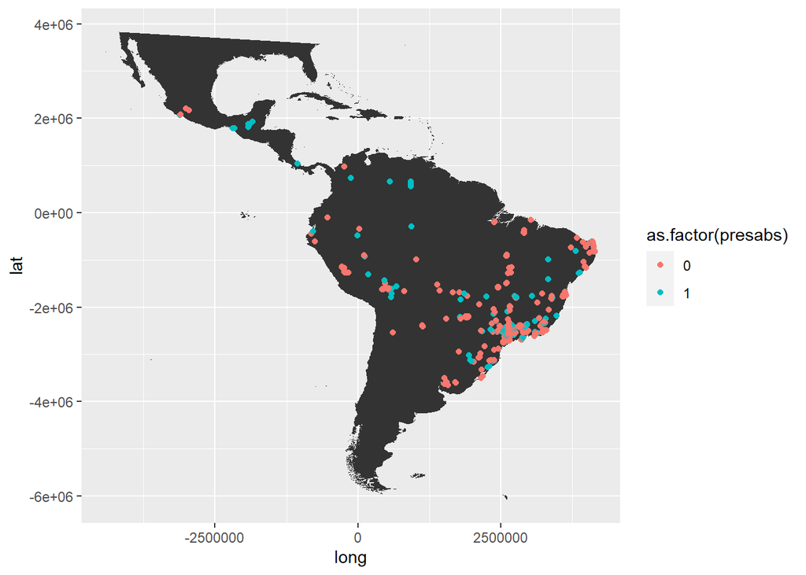

```r
# plot the data using ggplot2
ggplot() +
  geom_polygon(data  = fortify(Latam), aes(x=long, y=lat, group=group)) +
  geom_point(data = PA, aes(x=X, y=Y, colour=as.factor(presabs)))
```

# 7 Presence-absence methods - random forest

- Popular machine-learning approach
- Based on resampling of the data, and performing multiple **classification and regression trees (CART)**, whose predictions are then averaged
- Easy to use, miminal assumptions about the data
- Can be used for exploratory analysis

Fitting the random forest model

```r
library(randomForest)
rf <- randomForest(presabs ~ area + effort +
                             env.elev + env.npp +
                             env.bio_1 + env.bio_12 + env.bio_7 + env.bio_15,
                   data = PA)
```

Explore the results

```r
rf
```

```
##
## Call:
##  randomForest(formula = presabs ~ area + effort + env.elev + env.npp +      env.bio_1 + env.bio_12 + env.bio_7 + env.bio_15, data = PA)
##                Type of random forest: regression
##                      Number of trees: 500
## No. of variables tried at each split: 2
##
##           Mean of squared residuals: 0.1062435
##                     % Var explained: 28.05
```

```r
importance(rf)
```

```
##            IncNodePurity
## area           16.483254
## effort         10.135995
## env.elev        5.631007
## env.npp         6.003835
## env.bio_1       6.210072
## env.bio_12      6.254956
## env.bio_7       6.843808
## env.bio_15      5.953725
```

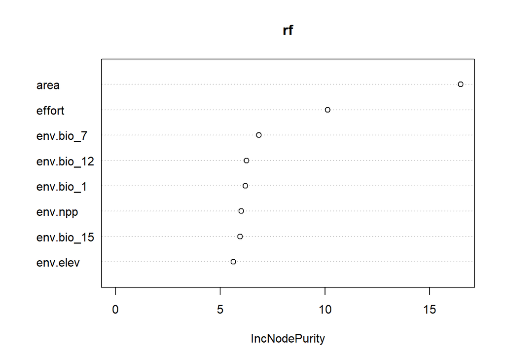

```r
varImpPlot(rf)
```

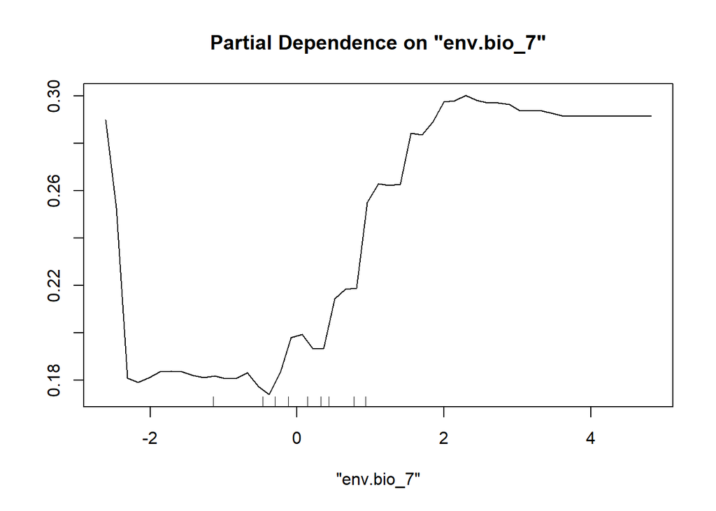

```r
partialPlot(rf, x.var="env.bio_7", pred.data = PA)
```

Put predictions on a map

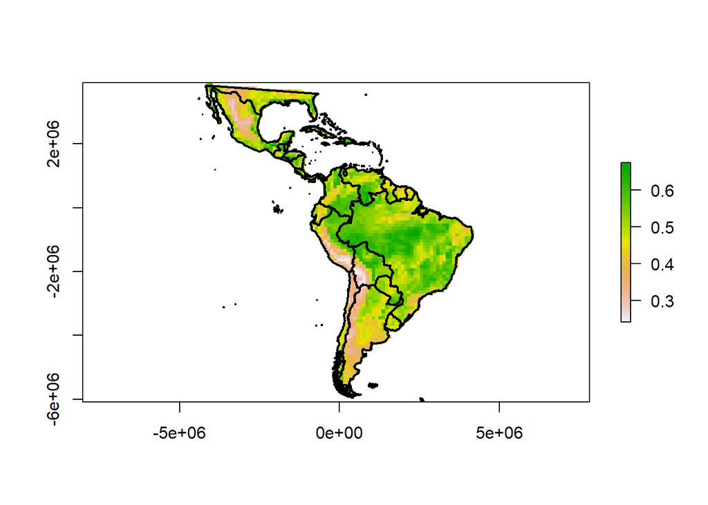

```r
# add effort columns to the raster data
PO <- data.frame(PO, effort = 500)

# generate predictions
rf.preds <- predict(rf, newdata = PO)

# create empty raster for the predictions
rf.raster <- Latam.raster

# put predictions to the raster
rf.raster[PO$pixel] <- rf.preds

# plot predictions
plot(rf.raster)
plot(Latam_countries, col=NA, lwd=2, add=T)
```

# 8 Presence-absence methods - Generalized Linear Models (GLM)

Fit the GLM

```r
m.glm <- glm(presabs ~ log(area) + log(effort) +
                    env.elev + env.npp +
                    env.bio_1 + env.bio_12 + env.bio_7 + env.bio_15,
                    data = PA,
                    family = "binomial")
```

Explore the results

```r
summary(m.glm)
```

```
##
## Call:
## glm(formula = presabs ~ log(area) + log(effort) + env.elev +
##     env.npp + env.bio_1 + env.bio_12 + env.bio_7 + env.bio_15,
##     family = "binomial", data = PA)
##
## Deviance Residuals:
##     Min       1Q   Median       3Q      Max
## -1.6773  -0.5952  -0.3877  -0.2266   3.1117
##
## Coefficients:
##             Estimate Std. Error z value Pr(>|z|)
## (Intercept) -8.21238    0.91463  -8.979  < 2e-16 ***
## log(area)    0.36439    0.05265   6.921 4.49e-12 ***
## log(effort)  0.12985    0.04755   2.731  0.00631 **
## env.elev    -0.91061    0.45081  -2.020  0.04339 *
## env.npp      0.39539    0.18783   2.105  0.03529 *
## env.bio_1    0.24429    0.49564   0.493  0.62210
## env.bio_12   0.26627    0.27885   0.955  0.33964
## env.bio_7    0.12089    0.17320   0.698  0.48519
## env.bio_15  -0.73238    0.65748  -1.114  0.26531
## ---
## Signif. codes:  0 '***' 0.001 '**' 0.01 '*' 0.05 '.' 0.1 ' ' 1
##
## (Dispersion parameter for binomial family taken to be 1)
##
##     Null deviance: 445.12  on 471  degrees of freedom
## Residual deviance: 353.60  on 463  degrees of freedom
## AIC: 371.6
##
## Number of Fisher Scoring iterations: 5
```

```r
# termplot(m.glm, partial.resid=TRUE, se = TRUE)
```

Put predictions on a map

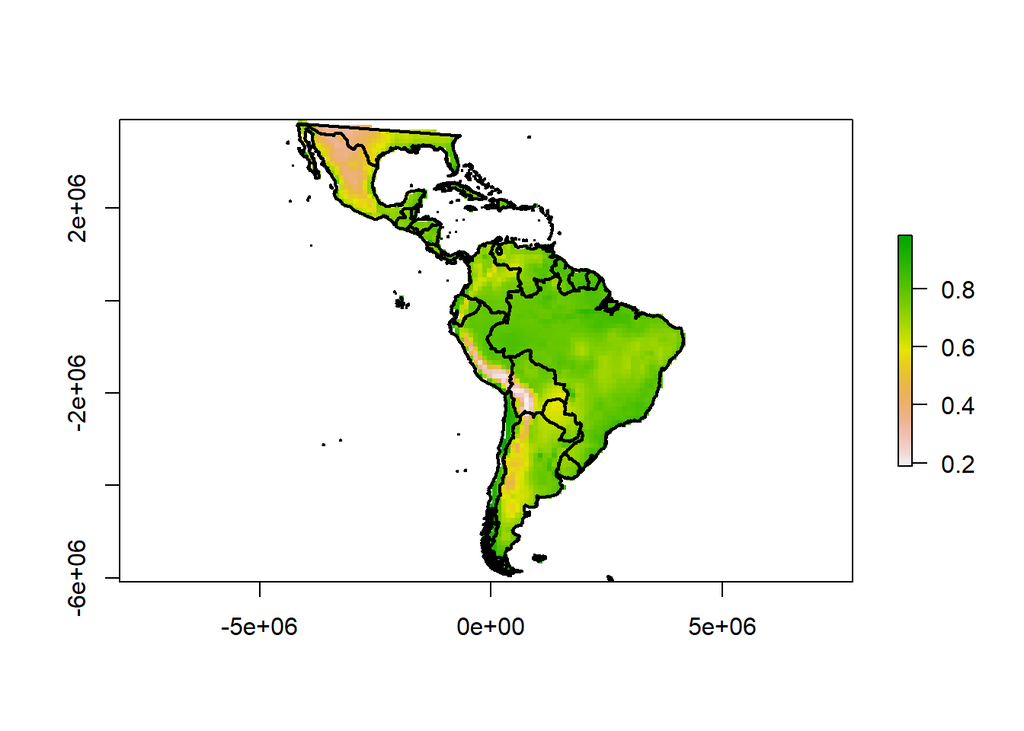

```r
# generate predictions
m.glm.preds <- predict(m.glm, newdata = PO, type = "response")

# create empty raster for the predictions
m.glm.raster <- Latam.raster

# put predictions to the raster
m.glm.raster[PO$pixel] <- m.glm.preds

# plot predictions
plot(m.glm.raster)
plot(Latam_countries, col=NA, lwd=2, add=T)
```

# 9 Presence-absence methods - Generalized Additive Models (GAM)

```r
m.gam <- gam(presabs ~ log(area) + log(effort) + s(X, Y) +
                    env.elev + env.npp +
                    env.bio_1 + env.bio_12 + env.bio_7 + env.bio_15,
                    data = PA,
                    family = "binomial")
```

Explore the results

```r
summary(m.gam)
```

```
##
## Family: binomial
## Link function: logit
##
## Formula:
## presabs ~ log(area) + log(effort) + s(X, Y) + env.elev + env.npp +
##     env.bio_1 + env.bio_12 + env.bio_7 + env.bio_15
##
## Parametric coefficients:
##             Estimate Std. Error z value Pr(>|z|)
## (Intercept) -9.01194    1.04478  -8.626  < 2e-16 ***
## log(area)    0.35331    0.06255   5.648 1.62e-08 ***
## log(effort)  0.25846    0.08237   3.138   0.0017 **
## env.elev    -1.61284    1.28571  -1.254   0.2097
## env.npp      0.10488    0.25355   0.414   0.6791
## env.bio_1    1.74036    1.74174   0.999   0.3177
## env.bio_12   0.73526    0.51998   1.414   0.1574
## env.bio_7    0.46405    0.32238   1.439   0.1500
## env.bio_15  -2.86146    1.48283  -1.930   0.0536 .
## ---
## Signif. codes:  0 '***' 0.001 '**' 0.01 '*' 0.05 '.' 0.1 ' ' 1
##
## Approximate significance of smooth terms:
##          edf Ref.df Chi.sq p-value
## s(X,Y) 19.45  23.89  39.76   0.025 *
## ---
## Signif. codes:  0 '***' 0.001 '**' 0.01 '*' 0.05 '.' 0.1 ' ' 1
##
## R-sq.(adj) =  0.346   Deviance explained = 35.5%
## UBRE = -0.27093  Scale est. = 1         n = 472
```

Put predictions on a map

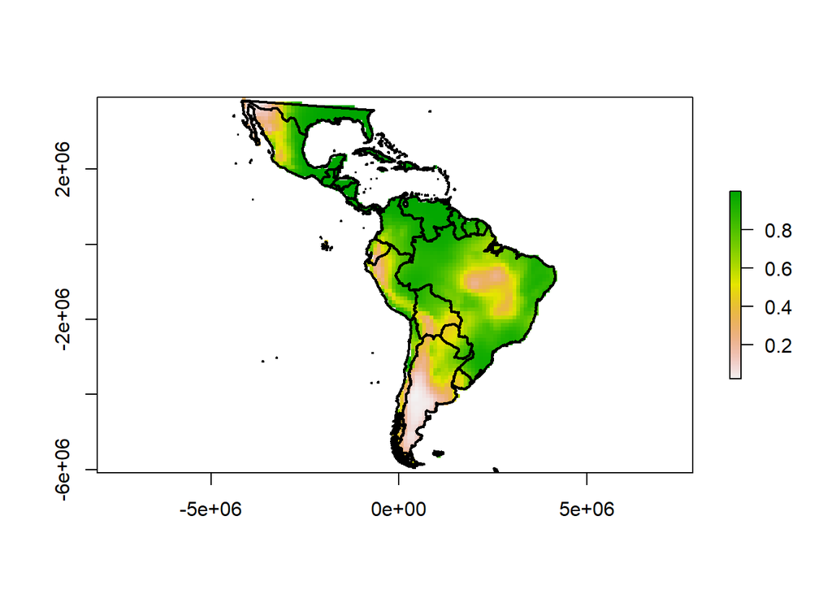

```r
# generate predictions
m.gam.preds <- predict(m.gam, newdata = PO, type = "response")

# create empty raster for the predictions
m.gam.raster <- Latam.raster

# put predictions to the raster
m.gam.raster[PO$pixel] <- m.gam.preds

# plot predictions
plot(m.gam.raster)
plot(Latam_countries, col=NA, lwd=2, add=T)
```

# 10 Comparisons and conclusions

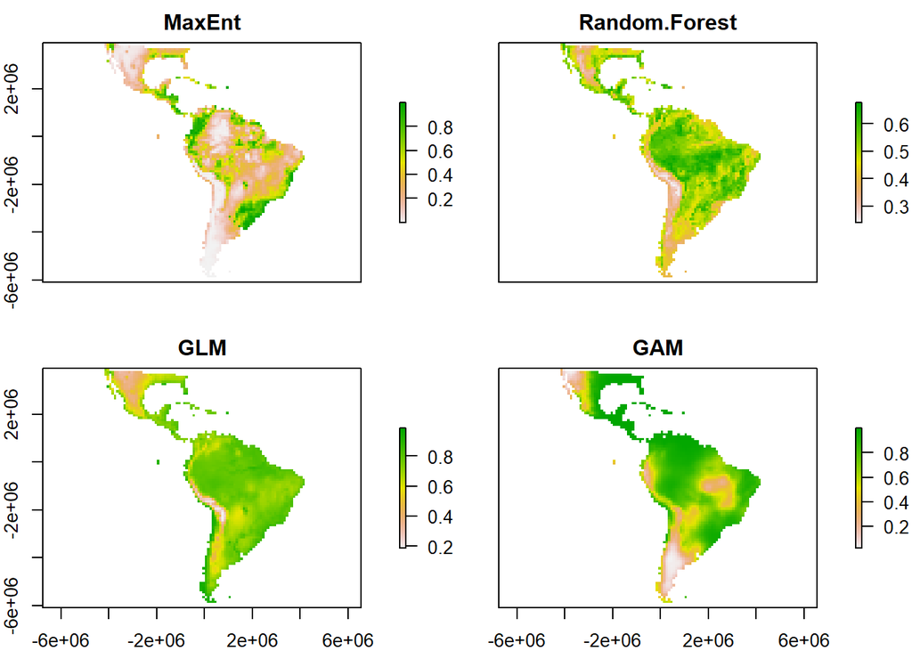

```r
all.preds <- raster::stack(mx.raster, rf.raster, m.glm.raster, m.gam.raster)
names(all.preds) <- c("MaxEnt", "Random Forest", "GLM", "GAM")
plot(all.preds)
```

And here is the simplest application of **model averaging**, a.k.a. **ensemble modelling**:

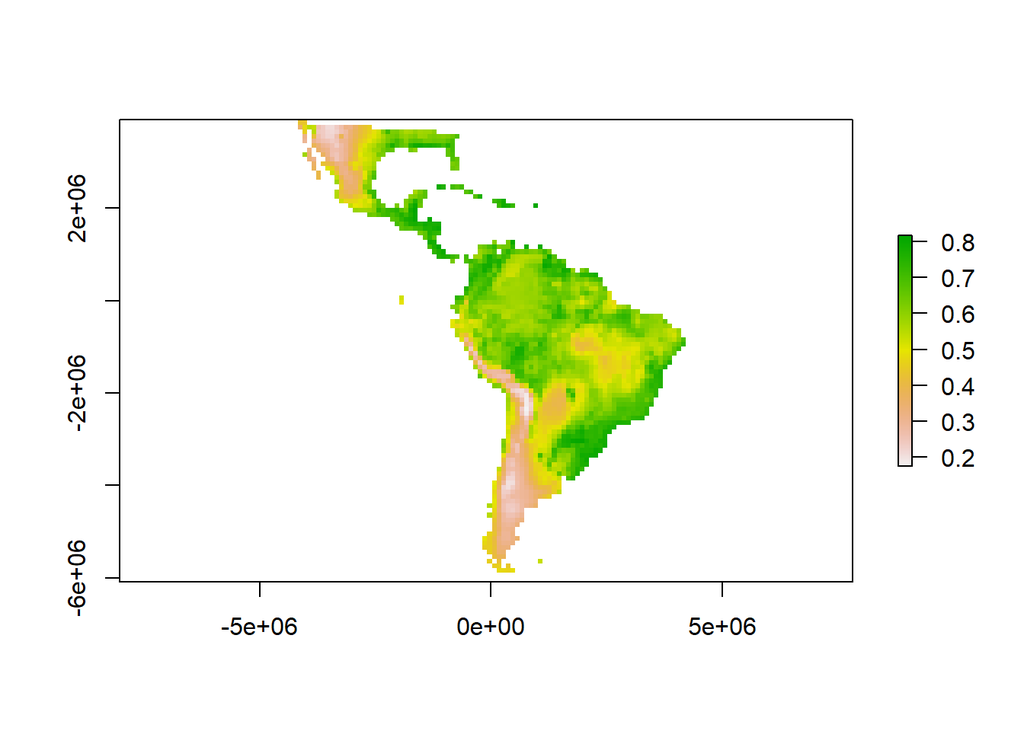

```r
plot(mean(all.preds))
```

# 11 Things to consider

- low R2 of all models
- collinearity
- non-linear effects